# Chocolate

```r
View(choc)
```

**Comments to Critiquers:** As respectfully as possilbe I urge you not to mark me down because of critiques based on opinion and not actual errors in the document. I will openly admit my critique is far from perfect, however please grade me on those things which pertain to the rubric. Thank you!

## Background

### Overview

The Data collected and contained in this analysis is in regardes to chocolate companies, thier locations, the rating of thier choclate and other details. Please refer to the tabs containing the data sets for more consise infromation on dataset. The data contained ranges from 2006 to 2017.

upon review of the data a question was posed, Does the quality of chocolate increase over time?

### Period 1 Data

```r
choc$Period <- cut(choc$Review, breaks = 4, labels = c("1", "2", "3", "4"))

d1 <- subset(choc, Period == 1)
pander(d1, split.tables = Inf)
```

| Company | Orig | Review | Cocao | Location | Rating | Type | BroadOrig | Period |
| --- | --- | --- | --- | --- | --- | --- | --- | --- |
| Amano | Bali, Jembrana | 2008 | 70% | U.S.A. | 2.75 | A | Indonesia | 1 |
| Amano | Cuyagua | 2007 | 70% | U.S.A. | 3 | A | Venezuela | 1 |
| Bittersweet Origins | Bocas del Toro | 2008 | 75% | U.S.A. | 3.5 | A | Panama | 1 |
| Bittersweet Origins | Puerto Plata | 2008 | 68% | U.S.A. | 3.75 | A | Dominican Republic | 1 |
| Black Mountain | La Red | 2008 | 70% | U.S.A. | 2.75 | A | Dominican Republic | 1 |
| Black Mountain | Matiguas | 2008 | 70% | U.S.A. | 3 | A | Nicaragua | 1 |
| Bonnat | Ocumare, Puerto Cabello | 2006 | 75% | France | 4 | A | Venezuela | 1 |
| Bonnat | One Hundred | 2006 | 100% | France | 1.5 | A |  | 1 |
| Bonnat | Ceylan | 2006 | 75% | France | 3 | A | Sri Lanka | 1 |
| Cacao Barry | Tanzania | 2008 | 75% | France | 2 | A | Tanzania | 1 |
| Cacao Barry | Venezuela | 2007 | 72% | France | 2 | A | Venezuela | 1 |
| Cacao Barry | Mexico | 2007 | 66% | France | 3 | A | Mexico | 1 |
| Callebaut | Baking | 2007 | 70% | Belgium | 1 | A | Ecuador | 1 |
| Compania de Chocolate (Salgado) | Moxos | 2008 | 72% | Argentina | 3.25 | A | Bolivia | 1 |
| Cote d’ Or (Kraft) | Sensations Intense | 2006 | 70% | Belgium | 1 | A |  | 1 |
| Dean and Deluca (Belcolade) | Costa Rica | 2007 | 64% | U.S.A. | 3 | A | Costa Rica | 1 |
| Dean and Deluca (Belcolade) | Ecuador | 2007 | 71% | U.S.A. | 3 | A | Ecuador | 1 |
| Dean and Deluca (Belcolade) | Papua New Guinea | 2007 | 64% | U.S.A. | 3 | A | Papua New Guinea | 1 |
| Dean and Deluca (Belcolade) | Peru | 2007 | 64% | U.S.A. | 3 | A | Peru | 1 |
| Debauve & Gallais (Michel Cluizel) | Venezuela | 2008 | 66% | France | 3.75 | A | Venezuela | 1 |
| DeVries | Bolivian | 2008 | 80% | U.S.A. | 2.75 | A | Bolivia | 1 |
| DeVries | Dominican Republic | 2007 | 77% | U.S.A. | 3.5 | A | Dominican Republic | 1 |
| Dolfin (Belcolade) | Noir | 2006 | 70% | Belgium | 1.5 | A |  | 1 |
| Domori | Teyuna | 2008 | 70% | Italy | 3 | A | Colombia | 1 |
| El Ceibo | Alto Beni | 2008 | 71% | Bolivia | 2.75 | A | Bolivia | 1 |
| Felchlin | Supremo- SF | 2006 | 62% | Switzerland | 2 | A |  | 1 |
| Green & Black’s (ICAM) | Dark | 2006 | 70% | U.K. | 2.5 | A |  | 1 |
| Guittard | Machu Pichu | 2008 | 65% | U.S.A. | 3 | A | Peru | 1 |
| Guittard | Special Maker Reserve | 2008 | 64% | U.S.A. | 3 | A |  | 1 |
| Guittard | Ocumare | 2008 | 65% | U.S.A. | 3.5 | A | Venezuela | 1 |

[output cut: 212 more lines]

### Period 2 Data

```r
d2 <- subset(choc, Period == 2)
pander(d2, split.tables = Inf)
```

| Company | Orig | Review | Cocao | Location | Rating | Type | BroadOrig | Period |
| --- | --- | --- | --- | --- | --- | --- | --- | --- |
| Amano | Morobe | 2011 | 70% | U.S.A. | 4 | A | Papua New Guinea | 2 |
| Amano | Dos Rios | 2010 | 70% | U.S.A. | 3.75 | A | Dominican Republic | 2 |
| Amano | Guayas | 2010 | 70% | U.S.A. | 4 | A | Ecuador | 2 |
| Amano | Montanya | 2009 | 70% | U.S.A. | 3 | A | Venezuela | 2 |
| Amatller (Simon Coll) | Ecuador | 2009 | 70% | Spain | 2.75 | A | Ecuador | 2 |
| Amatller (Simon Coll) | Ecuador | 2009 | 85% | Spain | 2.75 | A | Ecuador | 2 |
| Artisan du Chocolat | Haiti | 2011 | 72% | U.K. | 4 | A | Haiti | 2 |
| Artisan du Chocolat | Panama | 2011 | 72% | U.K. | 2.75 | A | Panama | 2 |
| Artisan du Chocolat | Venezuela | 2010 | 100% | U.K. | 1.75 | A | Venezuela | 2 |
| Artisan du Chocolat | Costa Rica | 2010 | 72% | U.K. | 3.25 | A | Costa Rica | 2 |
| Artisan du Chocolat | Bali | 2010 | 72% | U.K. | 3.5 | A | Indonesia | 2 |
| Artisan du Chocolat | Brazil Rio Doce | 2009 | 72% | U.K. | 1.75 | A | Brazil | 2 |
| Belcolade | Costa Rica | 2010 | 64% | Belgium | 2.75 | A | Costa Rica | 2 |
| Belcolade | Papua New Guinea | 2010 | 64% | Belgium | 2.75 | A | Papua New Guinea | 2 |
| Belcolade | Peru | 2010 | 64% | Belgium | 2.75 | A | Peru | 2 |
| Belcolade | Ecuador | 2010 | 71% | Belgium | 3.5 | A | Ecuador | 2 |
| Beschle (Felchlin) | Indigena Amazonia, Grand Cru, Quizas | 2011 | 72% | Switzerland | 3.5 | A | Venezuela | 2 |
| Beschle (Felchlin) | Ecuador | 2011 | 72% | Switzerland | 4 | A | Ecuador | 2 |
| Beschle (Felchlin) | Java, Grand Cru | 2010 | 64% | Switzerland | 3.5 | A | Indonesia | 2 |
| Beschle (Felchlin) | Ocumare, Premier Cru, Quizas No. 2 | 2010 | 72% | Switzerland | 3.5 | A | Venezuela | 2 |
| Bittersweet Origins | Bali, Singaraja | 2010 | 75% | U.S.A. | 3.25 | A | Indonesia | 2 |
| Bittersweet Origins | Bali, Singaraja | 2010 | 65% | U.S.A. | 2.75 | A | Indonesia | 2 |
| Bittersweet Origins | Puerto Plata | 2009 | 75% | U.S.A. | 3 | A | Dominican Republic | 2 |
| Bittersweet Origins | Puerto Plata | 2009 | 65% | U.S.A. | 3.5 | A | Dominican Republic | 2 |
| Blanxart | Organic Dark | 2009 | 72% | Spain | 2.75 | A |  | 2 |
| Bonnat | Cusco, Cacao Cusco | 2011 | 75% | France | 3.5 | A | Peru | 2 |
| Bonnat | Libanio | 2011 | 75% | France | 3.75 | A | Brazil | 2 |
| Bonnat | Haiti | 2011 | 75% | France | 4 | A | Haiti | 2 |
| Bonnat | Juliana | 2011 | 75% | France | 3.5 | A | Brazil | 2 |
| Bonnat | Ivory Coast | 2009 | 75% | France | 3 | A | Ivory Coast | 2 |

[output cut: 368 more lines]

### Period 3 Data

```r
d3 <- subset(choc, Period == 3)
pander(d3, split.tables = Inf)
```

| Company | Orig | Review | Cocao | Location | Rating | Type | BroadOrig | Period |
| --- | --- | --- | --- | --- | --- | --- | --- | --- |
| A. Morin | Cuba | 2014 | 70% | France | 3.5 | A | Cuba | 3 |
| A. Morin | Pablino | 2014 | 70% | France | 4 | A | Peru | 3 |
| A. Morin | Panama | 2013 | 70% | France | 2.75 | A | Panama | 3 |
| A. Morin | Brazil | 2013 | 70% | France | 3.25 | A | Brazil | 3 |
| A. Morin | Equateur | 2013 | 70% | France | 3.75 | A | Ecuador | 3 |
| A. Morin | Colombie | 2013 | 70% | France | 2.75 | A | Colombia | 3 |
| A. Morin | Birmanie | 2013 | 70% | France | 3 | A | Burma | 3 |
| A. Morin | Papua New Guinea | 2013 | 70% | France | 3.25 | A | Papua New Guinea | 3 |
| A. Morin | Piura | 2013 | 70% | France | 3.25 | A | Peru | 3 |
| A. Morin | Chanchamayo Province | 2013 | 70% | France | 3.5 | A | Peru | 3 |
| A. Morin | Chanchamayo Province | 2013 | 63% | France | 4 | A | Peru | 3 |
| A. Morin | Bolivia | 2012 | 70% | France | 3.5 | A | Bolivia | 3 |
| A. Morin | Peru | 2012 | 63% | France | 3.75 | A | Peru | 3 |
| Alain Ducasse | Piura, Perou | 2013 | 75% | France | 2.5 | A | Peru | 3 |
| Altus aka Cao Artisan | Sur del Lago | 2013 | 60% | U.S.A. | 2.5 | A | Venezuela | 3 |
| Altus aka Cao Artisan | Bolivia | 2013 | 80% | U.S.A. | 3.25 | A | Bolivia | 3 |
| Altus aka Cao Artisan | Bolivia | 2013 | 60% | U.S.A. | 3 | A | Bolivia | 3 |
| Altus aka Cao Artisan | Peru | 2013 | 60% | U.S.A. | 3.25 | A | Peru | 3 |
| Amazona | LamasdelChanka, San Martin, Oro Verde coop | 2013 | 72% | Peru | 3.25 | A | Peru | 3 |
| Amedei | Piura, Blanco de Criollo | 2012 | 70% | Italy | 3.75 | A | Peru | 3 |
| Anahata | Elvesia | 2014 | 75% | U.S.A. | 3 | A | Dominican Republic | 3 |
| Ara | Chiapas | 2014 | 72% | France | 2.5 | A | Mexico | 3 |
| Ara | Equateur | 2014 | 75% | France | 2.75 | A | Ecuador | 3 |
| Ara | Trincheras | 2014 | 75% | France | 3 | A | Venezuela | 3 |
| Artisan du Chocolat | Colombia, Casa Luker | 2012 | 72% | U.K. | 3.75 | A | Colombia | 3 |
| Bahen & Co. | Bahia | 2012 | 70% | Australia | 2.5 | A | Brazil | 3 |
| Bar Au Chocolat | Duarte Province | 2012 | 70% | U.S.A. | 3.25 | A | Dominican Republic | 3 |
| Bar Au Chocolat | Chiapas | 2012 | 70% | U.S.A. | 3.5 | A | Mexico | 3 |
| Baravelli’s | single estate | 2012 | 80% | Wales | 2.75 | A | Costa Rica | 3 |
| Bernachon | Nature | 2012 | 55% | France | 2.75 | A |  | 3 |

[output cut: 596 more lines]

### Period 4 Data

```r
d4 <- subset(choc, Period == 4)
pander(d4, split.tables = Inf)
```

| Company | Orig | Review | Cocao | Location | Rating | Type | BroadOrig | Period |
| --- | --- | --- | --- | --- | --- | --- | --- | --- |
| A. Morin | Agua Grande | 2016 | 63% | France | 3.75 | A | Sao Tome | 4 |
| A. Morin | Kpime | 2015 | 70% | France | 2.75 | A | Togo | 4 |
| A. Morin | Atsane | 2015 | 70% | France | 3 | A | Togo | 4 |
| A. Morin | Akata | 2015 | 70% | France | 3.5 | A | Togo | 4 |
| A. Morin | Quilla | 2015 | 70% | France | 3.5 | A | Peru | 4 |
| Acalli | Chulucanas, El Platanal | 2015 | 70% | U.S.A. | 3.75 | A | Peru | 4 |
| Altus aka Cao Artisan | Momotombo | 2016 | 60% | U.S.A. | 2.75 | A | Nicaragua | 4 |
| Altus aka Cao Artisan | Acopagro | 2016 | 60% | U.S.A. | 3 | A | Peru | 4 |
| Altus aka Cao Artisan | CIAAB Coop | 2016 | 60% | U.S.A. | 2.5 | A | Bolivia | 4 |
| Altus aka Cao Artisan | Villa Andina | 2016 | 60% | U.S.A. | 2.5 | A | Peru | 4 |
| Altus aka Cao Artisan | Gruppo Salinas | 2016 | 60% | U.S.A. | 2.75 | A | Ecuador | 4 |
| Ambrosia | Dominican Republic | 2015 | 75% | Canada | 3.25 | A | Dominican Republic | 4 |
| Ambrosia | Papua New Guinea | 2015 | 63% | Canada | 3.25 | A | Papua New Guinea | 4 |
| Ambrosia | Venezuela | 2015 | 70% | Canada | 3.25 | A | Venezuela | 4 |
| Ambrosia | Peru | 2015 | 68% | Canada | 3.5 | A | Peru | 4 |
| Animas | Alto Beni | 2016 | 75% | U.S.A. | 3.5 | A | Bolivia | 4 |
| Arete | Kokoa Kamili | 2016 | 70% | U.S.A. | 3.75 | A | Tanzania | 4 |
| Arete | Hacienda Victoria | 2016 | 70% | U.S.A. | 3.25 | A | Ecuador | 4 |
| Arete | Costa Esmeraldas | 2016 | 70% | U.S.A. | 3.25 | A | Ecuador | 4 |
| Arete | Lachua | 2016 | 70% | U.S.A. | 3.5 | A | Guatemala | 4 |
| Arete | Rugoso | 2016 | 70% | U.S.A. | 3.75 | A | Nicaragua | 4 |
| Arete | La Masica, FHIA | 2016 | 70% | U.S.A. | 3.5 | A | Honduras | 4 |
| Arete | Coto Brus, Terciopelo | 2016 | 70% | U.S.A. | 4 | A | Costa Rica | 4 |
| Arete | Elvesia | 2016 | 70% | U.S.A. | 3.75 | A | Dominican Republic | 4 |
| Arete | Matasawalevu | 2016 | 70% | U.S.A. | 3.25 | A | Fiji | 4 |
| Arete | Lam Dong | 2016 | 73% | U.S.A. | 3.25 | A | Vietnam | 4 |
| Arete | Fazenda Camboa | 2015 | 70% | U.S.A. | 3.5 | A | Brazil | 4 |
| Arete | Oko Caribe | 2015 | 70% | U.S.A. | 3.5 | A | Domincan Republic | 4 |
| Arete | Fazenda Camboa | 2015 | 75% | U.S.A. | 2.75 | A | Brazil | 4 |
| Arete | Guatemala | 2015 | 70% | U.S.A. | 3.25 | A | Guatemala | 4 |

[output cut: 498 more lines]

### Full Dataset

The choc data is shown here in the “wide data format”.

```r
#Show the full width of the "Wide" version of the choc data:
pander(choc, split.tables = Inf)
```

| Company | Orig | Review | Cocao | Location | Rating | Type | BroadOrig | Period |
| --- | --- | --- | --- | --- | --- | --- | --- | --- |
| A. Morin | Agua Grande | 2016 | 63% | France | 3.75 | A | Sao Tome | 4 |
| A. Morin | Kpime | 2015 | 70% | France | 2.75 | A | Togo | 4 |
| A. Morin | Atsane | 2015 | 70% | France | 3 | A | Togo | 4 |
| A. Morin | Akata | 2015 | 70% | France | 3.5 | A | Togo | 4 |
| A. Morin | Quilla | 2015 | 70% | France | 3.5 | A | Peru | 4 |
| A. Morin | Cuba | 2014 | 70% | France | 3.5 | A | Cuba | 3 |
| A. Morin | Pablino | 2014 | 70% | France | 4 | A | Peru | 3 |
| A. Morin | Panama | 2013 | 70% | France | 2.75 | A | Panama | 3 |
| A. Morin | Brazil | 2013 | 70% | France | 3.25 | A | Brazil | 3 |
| A. Morin | Equateur | 2013 | 70% | France | 3.75 | A | Ecuador | 3 |
| A. Morin | Colombie | 2013 | 70% | France | 2.75 | A | Colombia | 3 |
| A. Morin | Birmanie | 2013 | 70% | France | 3 | A | Burma | 3 |
| A. Morin | Papua New Guinea | 2013 | 70% | France | 3.25 | A | Papua New Guinea | 3 |
| A. Morin | Piura | 2013 | 70% | France | 3.25 | A | Peru | 3 |
| A. Morin | Chanchamayo Province | 2013 | 70% | France | 3.5 | A | Peru | 3 |
| A. Morin | Chanchamayo Province | 2013 | 63% | France | 4 | A | Peru | 3 |
| A. Morin | Bolivia | 2012 | 70% | France | 3.5 | A | Bolivia | 3 |
| A. Morin | Peru | 2012 | 63% | France | 3.75 | A | Peru | 3 |
| Acalli | Chulucanas, El Platanal | 2015 | 70% | U.S.A. | 3.75 | A | Peru | 4 |
| Alain Ducasse | Piura, Perou | 2013 | 75% | France | 2.5 | A | Peru | 3 |
| Altus aka Cao Artisan | Momotombo | 2016 | 60% | U.S.A. | 2.75 | A | Nicaragua | 4 |
| Altus aka Cao Artisan | Acopagro | 2016 | 60% | U.S.A. | 3 | A | Peru | 4 |
| Altus aka Cao Artisan | CIAAB Coop | 2016 | 60% | U.S.A. | 2.5 | A | Bolivia | 4 |
| Altus aka Cao Artisan | Villa Andina | 2016 | 60% | U.S.A. | 2.5 | A | Peru | 4 |
| Altus aka Cao Artisan | Gruppo Salinas | 2016 | 60% | U.S.A. | 2.75 | A | Ecuador | 4 |
| Altus aka Cao Artisan | Sur del Lago | 2013 | 60% | U.S.A. | 2.5 | A | Venezuela | 3 |
| Altus aka Cao Artisan | Bolivia | 2013 | 80% | U.S.A. | 3.25 | A | Bolivia | 3 |
| Altus aka Cao Artisan | Bolivia | 2013 | 60% | U.S.A. | 3 | A | Bolivia | 3 |
| Altus aka Cao Artisan | Peru | 2013 | 60% | U.S.A. | 3.25 | A | Peru | 3 |
| Amano | Morobe | 2011 | 70% | U.S.A. | 4 | A | Papua New Guinea | 2 |

[output cut: 1764 more lines]

## Analysis

**Hypothesis**
$$H_0: \mu_1 = \mu_1 \dots = \mu$$
$$H_a: \mu_i \neq \mu \text{ for at least one } i$$
$$\text{Level of Significance} = .05$$

```r
choc$Period <- cut(choc$Review, breaks = 4, labels = c("1", "2", "3", "4"))
```

**Kruskal-Wallis Test**

```r
pander(kruskal.test(Rating ~ Period, data = choc))
```

Kruskal-Wallis rank sum test: `Rating` by `Period`

| Test statistic | df | P value |
| --- | --- | --- |
| 10.04 | 3 | 0.01826 * |

From the Kruskal Wallis test we can see through the p-Value which is less than the level of significance, $p = .01826$, that there is at least on period whose mean is different or from a different population than the rest.

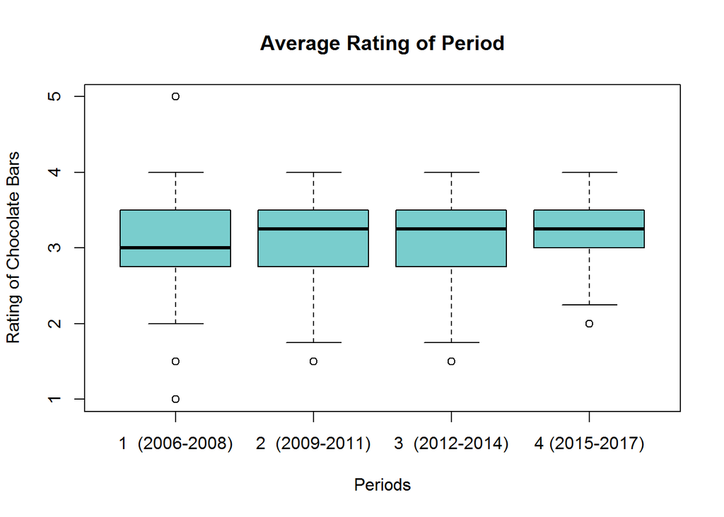

```r
boxplot(Rating ~ Period, data = choc, ylab = "Rating of Chocolate Bars", xlab = "Periods", main = "Average Rating of Period", names = c("1  (2006-2008)", "2  (2009-2011)", "3  (2012-2014)", "4 (2015-2017)"), col = "darkslategray3")
```

The boxplot shows us that period 1 has a lower mean than the rest of the data.The most interensting information from this plot is how the means of the following 3 periods apear to be the same, as if there was no improvment in chocolate ratings as time goes on. Below is a table which displays all the summary infromation for each of the periods.

**Data Summary of Periods**

```r
pander(favstats(Rating ~ Period, data = choc))
```

| Period | min | Q1 | median | Q3 | max | mean | sd | n | missing |
| --- | --- | --- | --- | --- | --- | --- | --- | --- | --- |
| 1 | 1 | 2.75 | 3 | 3.5 | 5 | 3.087 | 0.6688 | 242 | 0 |
| 2 | 1.5 | 2.75 | 3.25 | 3.5 | 4 | 3.168 | 0.4781 | 398 | 0 |
| 3 | 1.5 | 2.75 | 3.25 | 3.5 | 4 | 3.188 | 0.4457 | 626 | 0 |
| 4 | 2 | 3 | 3.25 | 3.5 | 4 | 3.241 | 0.3957 | 528 | 0 |

Through this chart we can see that most things are similar between the last 3 periods including the median (3.25), the max (4), and Q3 (3.5).

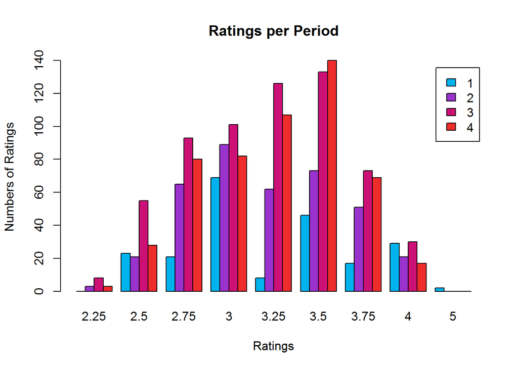

```r
tabledata <- subset(choc, Rating %in% c(2.25, 2.5, 2.75, 3, 3.25, 3.5, 3.75, 4, 4.25, 4.5, 4.75, 5))

counts <- table(tabledata$Period, tabledata$Rating)

barplot(counts, beside = TRUE, legend = rownames(counts), col = c("deepskyblue2", "darkorchid3", "deeppink3", "firebrick2"), xlab = "Ratings", ylab = "Numbers of Ratings", main = "Ratings per Period")
```